# PhenoCam API and Data Fusion

Bijan Seyednasrollah

2019-05-20

This R package is an effort to simplify data wrangling steps for fusion of PhenoCam time-series and other datasets.

Each PhenoCam site has specific metadata including but not limited to how a site is set up and where it is located, what vegetation type is visible from the camera, and its climate regime. Each PhenoCam may have none to several ROI’s per vegetation type. `phenocamapi` is an interface to interact with the PhenoCam server to extract those data and process them in an R environment.

I begin with several examples for extracting Phenocam data directly from the server:

- Exploring the PhenoCam metadata
- Downloading PhenoCam time-series data
- Merging with other time-series

## Exploriong the PhenoCam metadata

We can obtain an up-to-date `data.frame` of the metadata of the entire PhenoCam network using the `get_phenos()` function. The returning value would be a `data.table` in order to simplify further data exploration.

```r
library(data.table)
library(phenocamapi)

# obtaining the metadata as data.table
phenos <- get_phenos()
```

## Filtering the dataset using attributes

For example we can just list the sites that have flux tower:

```r
# store sites with flux_data available
phenofluxsites <- phenos[flux_data==TRUE&!is.na(flux_sitenames), .(PhenoCam=site, Flux=flux_sitenames)]

# see the first few rows
head(phenofluxsites)
```

```
#>                PhenoCam         Flux
#> 1:       alligatorriver       US-NC4
#> 2:        arscolesnorth         LTAR
#> 3:        arscolessouth         LTAR
#> 4: arsgreatbasinltar098       US-Rws
#> 5: arsgreatbasinltar177       US-Rms
#> 6:           arsmorris1 Unaffiliated
```

```r
#list deciduous broadleaf sites with flux tower
DB.flux <- phenos[flux_data==TRUE&primary_veg_type=='DB', site]

# see the first few rows
head(DB.flux)
```

```
#> [1] "alligatorriver" "bartlett"       "bartlettir"     "bbc3"
#> [5] "bbc4"           "bbc7"
```

## Downloading PhenoCam time-series data

PhenoCam time-series are extracted time-series data obtained from ROI’s for a given site.

To download the phenological time-series from the PhenoCam, we need to know the sitename, vegetation type and ROI ID. This information can be obtained from the [PhenoCam website](https://phenocam.sr.unh.edu/webcam/) or using the `get_rois()` function:

```r
# obtaining the list of all the available ROI's on the PhenoCam server
rois <- get_rois()

head(rois$roi_name)
```

```
#> [1] "alligatorriver_DB_1000"   "arbutuslake_DB_1000"
#> [3] "arbutuslakeinlet_DB_1000" "arbutuslakeinlet_EN_1000"
#> [5] "arbutuslakeinlet_EN_2000" "archboldavir_AG_1000"
```

```r
colnames(rois)
```

```
#>  [1] "roi_name"          "site"              "lat"
#>  [4] "lon"               "roitype"           "active"
#>  [7] "show_link"         "show_data_link"    "sequence_number"
#> [10] "description"       "first_date"        "last_date"
#> [13] "site_years"        "missing_data_pct"  "roi_page"
#> [16] "roi_stats_file"    "one_day_summary"   "three_day_summary"
#> [19] "data_release"
```

```r
# list all the ROI's for dukehw
rois[site=='dukehw',]
```

```
#>          roi_name   site      lat       lon roitype active show_link
#> 1: dukehw_DB_1000 dukehw 35.97358 -79.10037      DB   TRUE      TRUE
#>    show_data_link sequence_number
#> 1:           TRUE            1000
#>                                      description first_date  last_date
#> 1: canopy level DB forest at awesome Duke forest 2013-06-01 2019-05-20
#>    site_years missing_data_pct
#> 1:        5.7              4.0
#>                                                                   roi_page
#> 1: https://phenocam.sr.unh.edu/data/archive/dukehw/ROI/dukehw_DB_1000.html
#>                                                                     roi_stats_file
#> 1: https://phenocam.sr.unh.edu/data/archive/dukehw/ROI/dukehw_DB_1000_roistats.csv
#>                                                                one_day_summary
#> 1: https://phenocam.sr.unh.edu/data/archive/dukehw/ROI/dukehw_DB_1000_1day.csv
#>                                                              three_day_summary
#> 1: https://phenocam.sr.unh.edu/data/archive/dukehw/ROI/dukehw_DB_1000_3day.csv
#>    data_release
#> 1:          pre
```

The `get_pheno_ts()` function can download a time-series and return the result as a `data.table`. For example, to obtain the time-series for [DB_1000](https://phenocam.sr.unh.edu/data/archive/dukehw/ROI/dukehw_DB_1000.html) from the **dukehw** PhenoCam site, we can run the following code:

```r
# to obtain the DB 1000  from dukehw
dukehw_DB_1000 <- get_pheno_ts(site = 'dukehw', vegType = 'DB', roiID = 1000, type = '3day')

colnames(dukehw_DB_1000)
```

```
#>  [1] "date"                 "year"                 "doy"
#>  [4] "image_count"          "midday_filename"      "midday_r"
#>  [7] "midday_g"             "midday_b"             "midday_gcc"
#> [10] "midday_rcc"           "r_mean"               "r_std"
#> [13] "g_mean"               "g_std"                "b_mean"
#> [16] "b_std"                "gcc_mean"             "gcc_std"
#> [19] "gcc_50"               "gcc_75"               "gcc_90"
#> [22] "rcc_mean"             "rcc_std"              "rcc_50"
#> [25] "rcc_75"               "rcc_90"               "max_solar_elev"
#> [28] "snow_flag"            "outlierflag_gcc_mean" "outlierflag_gcc_50"
#> [31] "outlierflag_gcc_75"   "outlierflag_gcc_90"   "YEAR"
#> [34] "DOY"                  "YYYYMMDD"
```

```r
dukehw_DB_1000[,date:=as.Date(date)]
dukehw_DB_1000[,plot(date, gcc_90, col = 'green', type = 'b')]
```

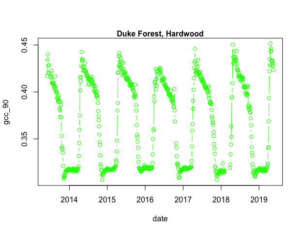

```r
mtext('Duke Forest, Hardwood', font = 2)
```

## Merge with other time-series such as flux data

In a fully programmatic settings you can load the PhenoCam dataset, find the related flux data, load the flux data and merge everything together as follows:

```r
phenots <- get_pheno_ts(site = 'oregonMP', vegType = 'EN', roiID = 1000)

colnames(phenots)
```

```
#>  [1] "date"                 "year"                 "doy"
#>  [4] "image_count"          "midday_filename"      "midday_r"
#>  [7] "midday_g"             "midday_b"             "midday_gcc"
#> [10] "midday_rcc"           "r_mean"               "r_std"
#> [13] "g_mean"               "g_std"                "b_mean"
#> [16] "b_std"                "gcc_mean"             "gcc_std"
#> [19] "gcc_50"               "gcc_75"               "gcc_90"
#> [22] "rcc_mean"             "rcc_std"              "rcc_50"
#> [25] "rcc_75"               "rcc_90"               "max_solar_elev"
#> [28] "snow_flag"            "outlierflag_gcc_mean" "outlierflag_gcc_50"
#> [31] "outlierflag_gcc_75"   "outlierflag_gcc_90"   "YEAR"
#> [34] "DOY"                  "YYYYMMDD"
```

```r
fluxfile <- system.file('fluxnetrepo/FLX_US-Me2/FLX_US-Me2_FULLSET_DD.csv', package = 'phenocamapi')

fluxts <- read.csv(fluxfile, skip = 0)
fluxts[fluxts==-9999] <- NA
fluxts <- as.data.table(fluxts)
fluxts[,datetime:=as.POSIXct(as.character(TIMESTAMP), format='%Y%m%d')]
fluxts[,YYYYMMDD:=as.character(as.Date(datetime))]
fluxts[,YEAR:=year(datetime)]
fluxts[,DOY:=yday(datetime)]

head(fluxts[, .(TIMESTAMP, TA_F)])
```

```
#>    TIMESTAMP    TA_F
#> 1:  20141115 -10.105
#> 2:  20141116  -8.044
#> 3:  20141117  -4.550
#> 4:  20141118  -1.584
#> 5:  20141119  -1.805
#> 6:  20141120   4.019
```